# Evaluating Machine Learning Models for Post-Tsunami Building Damage Detection

This is assessment for GEOG0125 which explores the use of 3-layer CNN model, MobileNetV2 and DenseNet121 in detecting washed-away buildings after a tsunami in Japan

### Set Up

```python
# library load
import os
import pandas as pd
import numpy as np
import matplotlib.pyplot as plt
from tensorflow.keras.utils import Sequence
from tensorflow.keras.models import Sequential
from tensorflow.keras.layers import Conv2D, MaxPooling2D, Flatten, Dense, Dropout
import tensorflow as tf
import tifffile as tiff
from sklearn.model_selection import train_test_split
import seaborn as sns
from sklearn.metrics import confusion_matrix
# used for exploring tif images
import tifffile as tiff
from tifffile import imread
```

```python
# directories set up for images and CSV files
root_dir = 'C:/Users/woron/Dropbox/UCL/GEOG0125 Advanced Topics in Social and Geographic Data Science 2324/ABCDDataset/ABCDdataset/resized/'
csv_dir = os.path.join(root_dir, '5fold-list')
image_dir = os.path.join(root_dir, 'patch-pairs')
train_csv = os.path.join(root_dir, '5fold-list/cv1-train.csv')
test_csv = os.path.join(root_dir, '5fold-list/cv1-test.csv')
```

### Data Exploration

```python
# defining function to visualize and load data
def load_and_visualize(path):
    df = pd.read_csv(path, header=None, names=['filename', 'label'])
    print(df.head())

    class_distribution = df['label'].value_counts().reset_index()
    class_distribution.columns = ['Label', 'Count']
    print("\nClass Distribution:")
    print(class_distribution)
```

```python
# train data
cv1_labels = pd.read_csv(train_csv, header=None, names=['filename', 'label'])
load_and_visualize(train_csv)
```

```
                                filename  label
0  1_____B_4_2_303_314_316_1264_0001.tif      1
1  1_____B_4_2_303_314_316_4768_0001.tif      1
2  1_____B_4_2_303_314_316_2284_0001.tif      1
3  1_____B_4_2_303_314_316_1033_0001.tif      1
4  1_____B_4_2_303_314_316_2402_0001.tif      1

Class Distribution:
   Label  Count
0      1   3378
1      0   3374
```

```python
# test data
cv1_labels_test = pd.read_csv(test_csv, header=None, names=['filename', 'label'])
load_and_visualize(test_csv)
```

```
                                 filename  label
0    1_____B_4_2_303_314_316_973_0001.tif      1
1   1_____B_4_2_303_314_316_2305_0001.tif      1
2   1_____B_4_2_303_314_316_1291_0001.tif      1
3  1_____B_4_2_303_314_316_13472_0001.tif      1
4  1_____B_4_2_303_314_316_12953_0001.tif      1

Class Distribution:
   Label  Count
0      0    847
1      1    845
```

##### The first field is file name and the second field represents class label of the file in the first field ("1" for "washed-away" and "0" for "surviving").

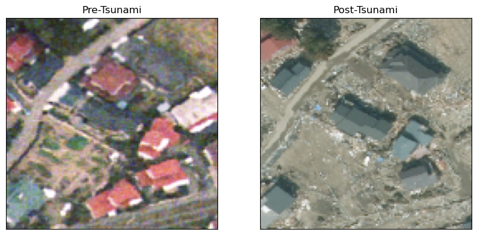

```python
# image exploration
example1 = os.path.join(root_dir, 'patch-pairs', '1_____B_4_2_303_314_316_973_0001.tif')
image = tiff.imread(example1)

# first 3 channels of .tif include a pre-tsunami image, the post-tsunami image is the last 3 channels of .tif
pre_tsunami_image = image[:, :, :3]
post_tsunami_image = image[:, :, 3:6]

# visualization
fig, axs = plt.subplots(1, 2, figsize=(10, 5))

axs[0].imshow(pre_tsunami_image)
axs[0].set_title('Pre-Tsunami')

axs[1].imshow(post_tsunami_image)
axs[1].set_title('Post-Tsunami')

for ax in axs:
    ax.set_xticks([])
    ax.set_yticks([])

plt.show()
```

### Model Preparation

```python
# function to load image paths and corresponding labels from csv file
def load_image_paths_and_labels(csv_file):
    df = pd.read_csv(csv_file, header=None, names=['filename', 'label'])
    return df['filename'].tolist(), df['label'].tolist()

#function to load images from image directory
def load_images(image_paths, image_dir):
    images = []
    for path in image_paths:
        img = tiff.imread(os.path.join(image_dir, path))
        images.append(img)
    return np.array(images)

# normalizing pixel values to be in the range [0, 1] by dividing by 255.0.
def preprocess_images(images):
    images = images.astype('float32') / 255.0
    return images
```

#### Data Generator - image_shape 128x128; 6 channels

This data generator is designed to load batches of image data and corresponding labels on-the-fly for model training and evaluation. This is a required step since the project is based on large dataset and direct data load would not be possible due to memory capabilities of Python.

```python
#code consulted with chat GPT
class PatchPairsGenerator(Sequence):
    def __init__(self, csv_file, image_dir, batch_size=32, shuffle=True, normalize=True):
        self.df = pd.read_csv(csv_file, header=None, names=['filename', 'label'])
        self.image_dir = image_dir
        self.batch_size = batch_size
        self.shuffle = shuffle
        self.normalize = normalize
        self.indexes = np.arange(len(self.df))
        if self.shuffle:
            np.random.shuffle(self.indexes)

    def __len__(self):
        # Number of batches per epoch
        return int(np.ceil(len(self.df) / self.batch_size))

    def __getitem__(self, index):
        # Generate one batch of data
        batch_indexes = self.indexes[index*self.batch_size:(index+1)*self.batch_size]
        batch_filenames = self.df.loc[batch_indexes, 'filename'].values
        batch_labels = self.df.loc[batch_indexes, 'label'].values

        batch_images = np.array([self.load_image(os.path.join(self.image_dir, filename))
                                 for filename in batch_filenames])

        if self.normalize:
            batch_images = batch_images.astype('float32') / 255.0

        return batch_images, batch_labels

    def on_epoch_end(self):
        # Updates indexes after each epoch
        if self.shuffle:
            np.random.shuffle(self.indexes)

    def load_image(self, image_path):
        # Load and return an image
        return tiff.imread(image_path)
```

```python
train_generator = PatchPairsGenerator(train_csv, image_dir, batch_size=32, shuffle=True)
test_generator = PatchPairsGenerator(test_csv, image_dir, batch_size=32, shuffle=True)
```

```python
# function definition for visual inspection of data generator
def visualize_batch(images, labels, n_samples=10):
    for i in range(n_samples):
        plt.figure(figsize=(10, 5))
        # visualize only the last three channels (post-tsunami patches)
        rgb_image = images[i][:, :, 3:6]
        plt.imshow(rgb_image)
        plt.title(f"Label: {labels[i]}")
        plt.axis('off')
        plt.show()

# debugging info
def print_debug_info(generator):
    batch_images, batch_labels = generator[0]
    for filename, label in zip(generator.df.loc[:generator.batch_size-1, 'filename'], batch_labels):
        print(f"Filename: {filename}, Label: {label}")

# data shape validation
def check_data_shapes(generator):
    batch_images, batch_labels = generator[0]
    print(f"Image batch shape: {batch_images.shape}")
    print(f"Label batch shape: {batch_labels.shape}")
```

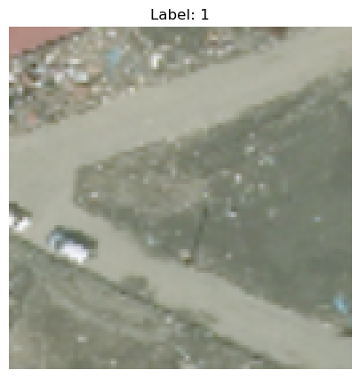

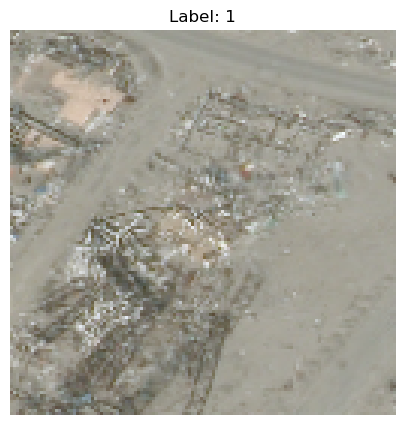

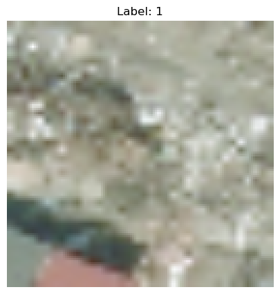

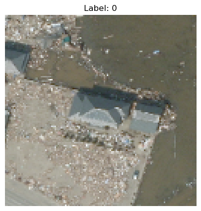

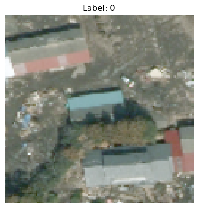

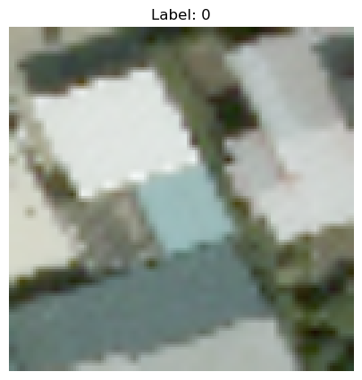

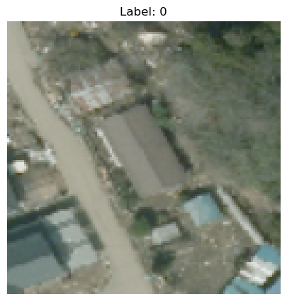

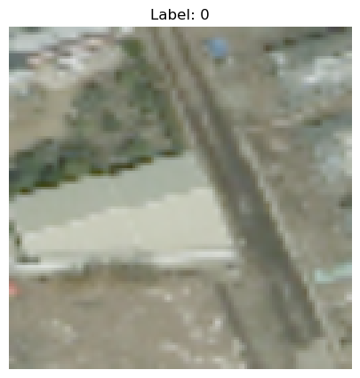

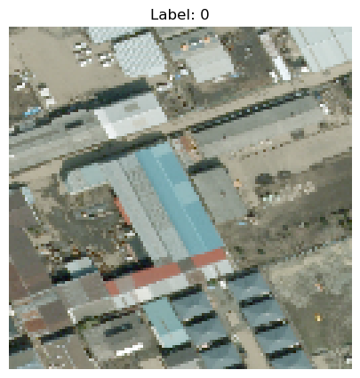

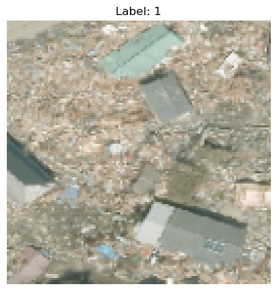

```
Filename: 1_____B_4_2_303_314_316_1264_0001.tif, Label: 1
Filename: 1_____B_4_2_303_314_316_4768_0001.tif, Label: 1
Filename: 1_____B_4_2_303_314_316_2284_0001.tif, Label: 1
Filename: 1_____B_4_2_303_314_316_1033_0001.tif, Label: 0
Filename: 1_____B_4_2_303_314_316_2402_0001.tif, Label: 0
Filename: 1_____B_4_2_303_314_316_1075_0001.tif, Label: 0
Filename: 1_____B_4_2_303_314_316_3419_0001.tif, Label: 0
Filename: 1_____B_4_2_303_314_316_12028_0001.tif, Label: 0
Filename: 1_____B_4_2_303_314_316_42_0001.tif, Label: 0
Filename: 1_____B_4_2_303_314_316_13487_0001.tif, Label: 1
Filename: 1_____B_4_2_303_314_316_1079_0001.tif, Label: 0
Filename: 1_____B_4_2_303_314_316_2696_0001.tif, Label: 1
Filename: 1_____B_4_2_303_314_316_13493_0001.tif, Label: 1
Filename: 1_____B_4_2_303_314_316_14926_0001.tif, Label: 0
Filename: 1_____B_4_2_303_314_316_16274_0001.tif, Label: 1
Filename: 1_____B_4_2_303_314_316_14461_0001.tif, Label: 1
Filename: 1_____B_4_2_303_314_316_1093_0001.tif, Label: 0
Filename: 1_____B_4_2_303_314_316_4303_0001.tif, Label: 0
Filename: 1_____B_4_2_303_314_316_103_0001.tif, Label: 0
Filename: 1_____B_4_2_303_314_316_2624_0001.tif, Label: 1
Filename: 1_____B_4_2_303_314_316_4737_0001.tif, Label: 0
Filename: 1_____B_4_2_303_314_316_2210_0001.tif, Label: 0
Filename: 1_____B_4_2_303_314_316_14307_0001.tif, Label: 1
Filename: 1_____B_4_2_303_314_316_14320_0001.tif, Label: 0
Filename: 1_____B_4_2_303_314_316_4340_0001.tif, Label: 1
Filename: 1_____B_4_2_303_314_316_4169_0001.tif, Label: 0
Filename: 1_____B_4_2_303_314_316_4490_0001.tif, Label: 0
Filename: 1_____B_4_2_303_314_316_15433_0001.tif, Label: 1
Filename: 1_____B_4_2_303_314_316_2306_0001.tif, Label: 0
Filename: 1_____B_4_2_303_314_316_1249_0001.tif, Label: 0
Filename: 1_____B_4_2_303_314_316_12939_0001.tif, Label: 1
Filename: 1_____B_4_2_303_314_316_1917_0001.tif, Label: 0
Image batch shape: (32, 128, 128, 6)
Label batch shape: (32,)
```

```python
# train data inspection
train_generator = PatchPairsGenerator(train_csv, image_dir, batch_size=32, shuffle=True)

# visual inspection
sample_images, sample_labels = train_generator[0]
visualize_batch(sample_images, sample_labels)

print_debug_info(train_generator)

check_data_shapes(train_generator)
```

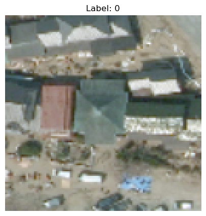

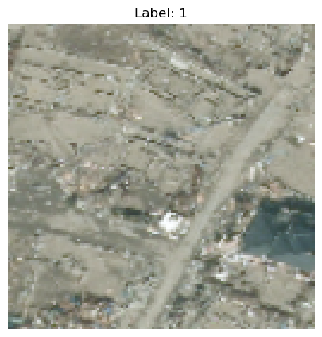

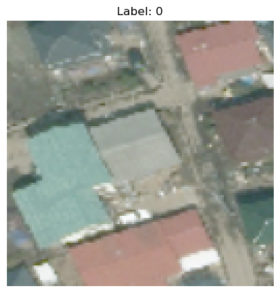

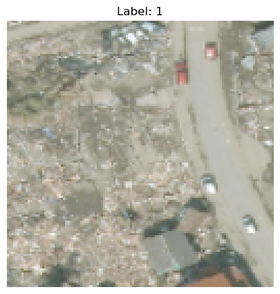

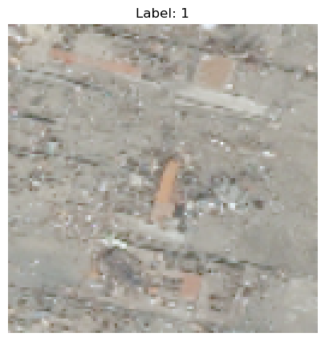

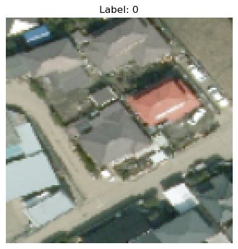

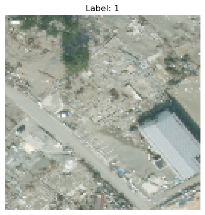

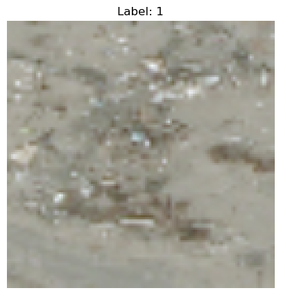

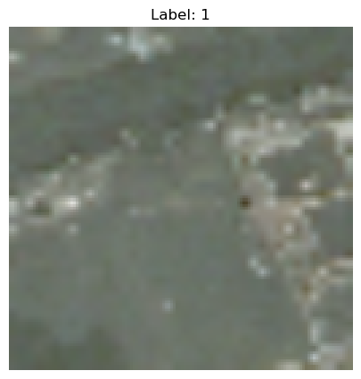

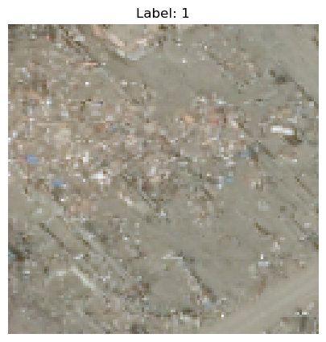

```
Filename: 1_____B_4_2_303_314_316_973_0001.tif, Label: 0
Filename: 1_____B_4_2_303_314_316_2305_0001.tif, Label: 1
Filename: 1_____B_4_2_303_314_316_1291_0001.tif, Label: 0
Filename: 1_____B_4_2_303_314_316_13472_0001.tif, Label: 1
Filename: 1_____B_4_2_303_314_316_12953_0001.tif, Label: 1
Filename: 1_____B_4_2_303_314_316_1829_0001.tif, Label: 0
Filename: 1_____B_4_2_303_314_316_972_0001.tif, Label: 1
Filename: 1_____B_4_2_303_314_316_11970_0001.tif, Label: 1
Filename: 1_____B_4_2_303_314_316_1318_0001.tif, Label: 1
Filename: 1_____B_4_2_303_314_316_1880_0001.tif, Label: 1
Filename: 1_____B_4_2_303_314_316_14081_0001.tif, Label: 1
Filename: 1_____B_4_2_303_314_316_13858_0001.tif, Label: 0
Filename: 1_____B_4_2_303_314_316_15578_0001.tif, Label: 1
Filename: 1_____B_4_2_303_314_316_12919_0001.tif, Label: 1
Filename: 1_____B_4_2_303_314_316_12210_0001.tif, Label: 0
Filename: 1_____B_4_2_303_314_316_12294_0001.tif, Label: 1
Filename: 1_____B_4_2_303_314_316_4492_0001.tif, Label: 1
Filename: 1_____B_4_2_303_314_316_15598_0001.tif, Label: 1
Filename: 1_____B_4_2_303_314_316_12979_0001.tif, Label: 0
Filename: 1_____B_4_2_303_314_316_11943_0001.tif, Label: 0
Filename: 1_____B_4_2_303_314_316_1113_0001.tif, Label: 1
Filename: 1_____B_4_2_303_314_316_2390_0001.tif, Label: 1
Filename: 1_____B_4_2_303_314_316_12023_0001.tif, Label: 0
Filename: 1_____B_4_2_303_314_316_4703_0001.tif, Label: 0
Filename: 1_____B_4_2_303_314_316_13134_0001.tif, Label: 1
Filename: 1_____B_4_2_303_314_316_14159_0001.tif, Label: 1
Filename: 1_____B_4_2_303_314_316_14682_0001.tif, Label: 0
Filename: 1_____B_4_2_303_314_316_13426_0001.tif, Label: 1
Filename: 1_____B_4_2_303_314_316_15847_0001.tif, Label: 1
Filename: 1_____B_4_2_303_314_316_15623_0001.tif, Label: 0
Filename: 1_____B_4_2_303_314_316_12293_0001.tif, Label: 0
Filename: 1_____B_4_2_303_314_316_201_0001.tif, Label: 0
Image batch shape: (32, 128, 128, 6)
Label batch shape: (32,)
```

```python
# test data inspection
test_generator = PatchPairsGenerator(test_csv, image_dir, batch_size=32, shuffle=True)

# visual inspection
sample_images, sample_labels = test_generator[0]
visualize_batch(sample_images, sample_labels)

print_debug_info(test_generator)

check_data_shapes(test_generator)
```

## CNN

### CNN Model Design

```python
from tensorflow.keras.models import Sequential
from tensorflow.keras.layers import Conv2D, MaxPooling2D, Flatten, Dense, Dropout

def create_cnn_model(input_shape):
    model = Sequential([
        Conv2D(32, (3, 3), activation='relu', input_shape=input_shape),
        MaxPooling2D((2, 2)),
        Conv2D(64, (3, 3), activation='relu'),
        MaxPooling2D((2, 2)),
        Conv2D(128, (3, 3), activation='relu'),
        MaxPooling2D((2, 2)),
        Flatten(),
        Dense(128, activation='relu'),
        Dropout(0.5),
        Dense(1, activation='sigmoid')
    ])

    model.compile(optimizer='adam', loss='binary_crossentropy', metrics=['accuracy'])
    return model

# 128x128 pixels with 6 channels
model = create_cnn_model((128, 128, 6))
```

[output not shown]

```python
# training model
history = model.fit(train_generator, epochs=10, validation_data=test_generator)
```

```python
model.save('damage_detection')
```

```
INFO:tensorflow:Assets written to: damage_detection\assets
```

```
INFO:tensorflow:Assets written to: damage_detection\assets
```

### CNN Model Testing

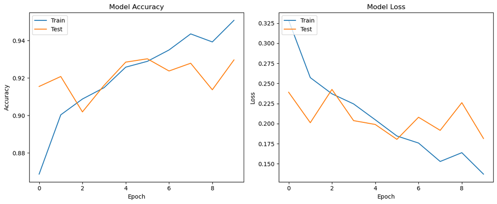

```python
plt.figure(figsize=(12, 5))
plt.subplot(1, 2, 1)
plt.plot(history.history['accuracy'])
plt.plot(history.history.get('val_accuracy', []))  # Optional: if validation accuracy is available
plt.title('Model Accuracy')
plt.ylabel('Accuracy')
plt.xlabel('Epoch')
plt.legend(['Train', 'Test'], loc='upper left')

# Plot training & validation loss values
plt.subplot(1, 2, 2)
plt.plot(history.history['loss'])
plt.plot(history.history.get('val_loss', []))  # Optional: if validation loss is available
plt.title('Model Loss')
plt.ylabel('Loss')
plt.xlabel('Epoch')
plt.legend(['Train', 'Test'], loc='upper left')

plt.tight_layout()
plt.show()
```

```python
from sklearn.metrics import confusion_matrix
import numpy as np

# Predictions
y_pred = []
y_true = []

for i in range(len(test_generator)):
    x, y = test_generator[i]
    y_pred.extend(model.predict(x).flatten()>0.5)
    y_true.extend(y)

# Convert predictions and true values to numpy arrays
y_pred = np.array(y_pred)
y_true = np.array(y_true)

# Confusion Matrix
cm = confusion_matrix(y_true, y_pred)

print("Confusion Matrix:")
print(cm)
```

```
Confusion Matrix:
[[788  59]
 [ 60 785]]
```

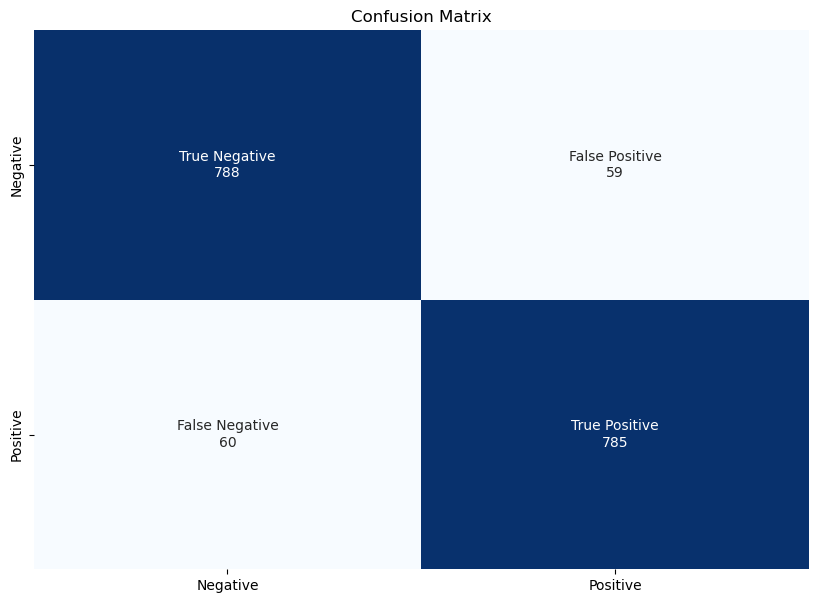

```python
cm = confusion_matrix(y_true, y_pred)

# Labels for the quadrants
group_names = ['True Negative', 'False Positive', 'False Negative', 'True Positive']

# Counts in each quadrant
group_counts = ["{0:0.0f}".format(value) for value in cm.flatten()]

# Combine names and counts into labels
group_labels = [f"{name}\n{n}" for name, n in zip(group_names, group_counts)]

# Reshape the labels to a 2x2 array
labels = np.asarray(group_labels).reshape(2,2)

plt.figure(figsize=(10, 7))
sns.heatmap(cm, annot=labels, fmt="", cmap="Blues", xticklabels=['Negative', 'Positive'], yticklabels=['Negative', 'Positive'], cbar=False)
plt.title('Confusion Matrix')
plt.show()
```

```python
from tensorflow.keras.models import load_model

# Load the model
model = load_model('damage_detection')
```

```python
import numpy as np

predictions = model.predict(test_generator)  # Assuming test_generator is your test data
# If your model ends with a sigmoid activation, threshold the predictions
y_pred = np.where(predictions > 0.5, 1, 0)
```

```python
cm = confusion_matrix(y_true, y_pred)
precision = precision_score(y_true, y_pred)
recall = recall_score(y_true, y_pred)
f1 = f1_score(y_true, y_pred)
accuracy = accuracy_score(y_true, y_pred)

print("Confusion Matrix:")
print(cm)
print(f"Precision: {precision:.4f}")
print(f"Recall: {recall:.4f}")
print(f"F1-score: {f1:.4f}")
print(f"Accuracy: {accuracy:.4f}")
```

```
Confusion Matrix:
[[788  59]
 [ 60 785]]
Precision: 0.9301
Recall: 0.9290
F1-score: 0.9295
Accuracy: 0.9297
```

## Post-tsunami only model design

To provide model with image shape with only 3 channels (as required for its full functioning, it will be fed with only post-tsunami images (3:6 channels of tif image)

```python
# function to load only 3 channels from tif
class PatchPairsGenerator(Sequence):
    def __init__(self, csv_file, image_dir, batch_size=32, shuffle=True):
        self.df = pd.read_csv(csv_file, header=None, names=['filename', 'label'])
        self.image_dir = image_dir
        self.batch_size = batch_size
        self.shuffle = shuffle
        self.indexes = np.arange(len(self.df))
        if self.shuffle:
            np.random.shuffle(self.indexes)

    def __len__(self):
        return int(np.ceil(len(self.df) / self.batch_size))

    def __getitem__(self, index):
        batch_indexes = self.indexes[index*self.batch_size:(index+1)*self.batch_size]
        batch_filenames = self.df.loc[batch_indexes, 'filename'].values
        batch_labels = self.df.loc[batch_indexes, 'label'].values

        batch_images = self.load_images(batch_filenames)
        batch_labels = np.array(batch_labels)

        # Normalize images
        batch_images = batch_images.astype('float32') / 255.0

        return batch_images, batch_labels

    def on_epoch_end(self):
        if self.shuffle:
            np.random.shuffle(self.indexes)

    def load_images(self, image_filenames):
        images = []
        for filename in image_filenames:
            img = tiff.imread(os.path.join(self.image_dir, filename))
            img = img[:, :, 3:6]  # Select post-tsunami channels
            images.append(img)
        return np.array(images)

train_generator = PatchPairsGenerator(train_csv, image_dir, batch_size=32, shuffle=True)
test_generator = PatchPairsGenerator(test_csv, image_dir, batch_size=32, shuffle=False)
```

## MobileNetV2

### MobileNetV2 Model Design, 128x128, 3 channels

```python
input_shape=(128,128,3)
```

```python
def create_mobilenetv2_model(input_shape, num_classes=1):  # Assuming num_classes is 1 for binary classification
    from tensorflow.keras.applications import MobileNetV2
    from tensorflow.keras.models import Model
    from tensorflow.keras.layers import GlobalAveragePooling2D, Dense
    # Load MobileNetV2 pre-trained on ImageNet dataset
    base_model = MobileNetV2(weights='imagenet', include_top=False, input_shape=input_shape)
    # Freeze all layers in the base model
    for layer in base_model.layers:
        layer.trainable = False
    # Add custom top layers
    x = base_model.output
    x = GlobalAveragePooling2D()(x)
    x = Dense(1024, activation='relu')(x)
    x = Dropout(0.5)(x)
    predictions = Dense(1, activation='sigmoid')(x)  # Changed this line for binary classification
    # Compile the model
    model = Model(inputs=base_model.input, outputs=predictions)
    model.compile(optimizer='adam', loss='binary_crossentropy', metrics=['accuracy'])
    return model
```

```python
model = create_mobilenetv2_model(input_shape=input_shape)
```

```python
# Train the model
history5 = model.fit(
    train_generator,
    epochs=10,
    validation_data=test_generator
)
```

```python
from tensorflow.keras.applications import ResNet50
from tensorflow.keras.models import Model
from tensorflow.keras.layers import Dense, GlobalAveragePooling2D, Dropout, Input
from tensorflow.keras.preprocessing.image import ImageDataGenerator
import numpy as np
import pandas as pd
import tifffile as tiff
import os
```

### MobileNetV2 Model Testing, 128x128, 3 channels

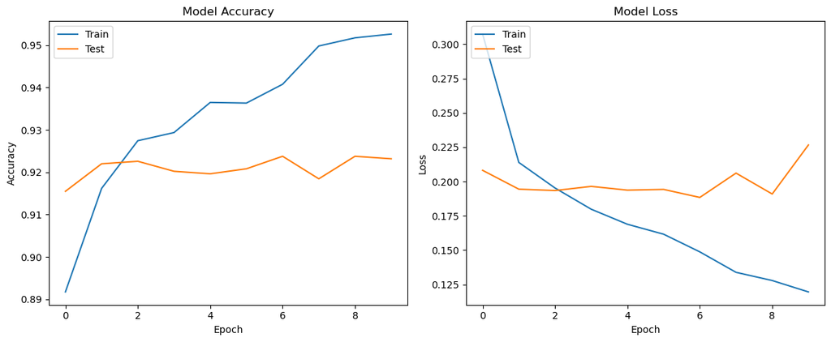

```python
plt.figure(figsize=(12, 5))
plt.subplot(1, 2, 1)
plt.plot(history5.history['accuracy'])
plt.plot(history5.history.get('val_accuracy', []))  # Optional: if validation accuracy is available
plt.title('Model Accuracy')
plt.ylabel('Accuracy')
plt.xlabel('Epoch')
plt.legend(['Train', 'Test'], loc='upper left')

# Plot training & validation loss values
plt.subplot(1, 2, 2)
plt.plot(history5.history['loss'])
plt.plot(history5.history.get('val_loss', []))  # Optional: if validation loss is available
plt.title('Model Loss')
plt.ylabel('Loss')
plt.xlabel('Epoch')
plt.legend(['Train', 'Test'], loc='upper left')

plt.tight_layout()
plt.show()
```

```python
# Predictions
y_pred = []
y_true = []

for i in range(len(test_generator)):
    x, y = test_generator[i]
    y_pred.extend(model.predict(x).flatten() > 0.5)
    y_true.extend(y)

# Convert predictions and true values to numpy arrays
y_pred = np.array(y_pred)
y_true = np.array(y_true)

# Confusion Matrix
cm = confusion_matrix(y_true, y_pred)

# Calculate Precision, Recall, F1-score, and Accuracy
precision = precision_score(y_true, y_pred)
recall = recall_score(y_true, y_pred)
f1 = f1_score(y_true, y_pred)
accuracy = accuracy_score(y_true, y_pred)

print("Confusion Matrix:")
print(cm)
print("Precision:", precision)
print("Recall:", recall)
print("F1-score:", f1)
print("Accuracy:", accuracy)
```

```
Confusion Matrix:
[[811  36]
 [ 94 751]]
Precision: 0.9542566709021602
Recall: 0.8887573964497042
F1-score: 0.9203431372549019
Accuracy: 0.9231678486997635
```

[figure not shown]

```python
cm = confusion_matrix(y_true, y_pred)

# Labels for the quadrants
group_names = ['True Negative', 'False Positive', 'False Negative', 'True Positive']

# Counts in each quadrant
group_counts = ["{0:0.0f}".format(value) for value in cm.flatten()]

# Combine names and counts into labels
group_labels = [f"{name}\n{n}" for name, n in zip(group_names, group_counts)]

# Reshape the labels to a 2x2 array
labels = np.asarray(group_labels).reshape(2,2)

plt.figure(figsize=(10, 7))
sns.heatmap(cm, annot=labels, fmt="", cmap="Blues", xticklabels=['Negative', 'Positive'], yticklabels=['Negative', 'Positive'], cbar=False)
plt.title('Confusion Matrix')
plt.show()
```

## DenseNet121

### DenseNet121 Model Design, 128x128, 3 channels

```python
from tensorflow.keras.backend import clear_session

# Clear TensorFlow's internal graph
clear_session()
```

```python
input_shape = (128, 128, 3)  # Height, Width, Channels
```

```python
# Now define your model
densenet121_model = create_densenet121_model(input_shape, num_classes)
```

```python
# function to load only 3 channels from tif

from tensorflow.keras.utils import Sequence
import numpy as np
import pandas as pd
import tifffile as tiff
import os

class PatchPairsGenerator(Sequence):
    def __init__(self, csv_file, image_dir, batch_size=32, shuffle=True):
        self.df = pd.read_csv(csv_file, header=None, names=['filename', 'label'])
        self.image_dir = image_dir
        self.batch_size = batch_size
        self.shuffle = shuffle
        self.indexes = np.arange(len(self.df))
        if self.shuffle:
            np.random.shuffle(self.indexes)

    def __len__(self):
        return int(np.ceil(len(self.df) / self.batch_size))

    def __getitem__(self, index):
        batch_indexes = self.indexes[index*self.batch_size:(index+1)*self.batch_size]
        batch_filenames = self.df.loc[batch_indexes, 'filename'].values
        batch_labels = self.df.loc[batch_indexes, 'label'].values

        batch_images = self.load_images(batch_filenames)
        batch_labels = np.array(batch_labels)

        # Normalize images
        batch_images = batch_images.astype('float32') / 255.0

        return batch_images, batch_labels

    def on_epoch_end(self):
        if self.shuffle:
            np.random.shuffle(self.indexes)

    def load_images(self, image_filenames):
        images = []
        for filename in image_filenames:
            img = tiff.imread(os.path.join(self.image_dir, filename))
            img = img[:, :, 3:6]  # Select channels 3 to 5
            images.append(img)
        return np.array(images)

# Example usage:
train_generator = PatchPairsGenerator(train_csv, image_dir, batch_size=32, shuffle=True)
test_generator = PatchPairsGenerator(test_csv, image_dir, batch_size=32, shuffle=False)
```

```python
input_shape = (128, 128, 3)  # Height, Width, Channels
```

```python
from tensorflow.keras.applications import DenseNet121
from tensorflow.keras.models import Model
from tensorflow.keras.layers import Dense, GlobalAveragePooling2D

def create_densenet121_model(input_shape):
    base_model = DenseNet121(weights='imagenet', include_top=False, input_shape=input_shape)
    for layer in base_model.layers:
        layer.trainable = False

    x = base_model.output
    x = GlobalAveragePooling2D()(x)
    x = Dense(1024, activation='relu')(x)
    predictions = Dense(1, activation='sigmoid')(x)  # Change for binary classification

    model = Model(inputs=base_model.input, outputs=predictions)
    model.compile(optimizer='adam', loss='binary_crossentropy', metrics=['accuracy'])
    return model

# Adjust input_shape and num_classes accordingly
densenet121_model = create_densenet121_model(input_shape)
```

```python
# Train the model
history6 = densenet121_model.fit(
    train_generator,
    epochs=10,
    validation_data=test_generator
)
```

### DenseNet121 Model Testing, 128x128, 3 channels

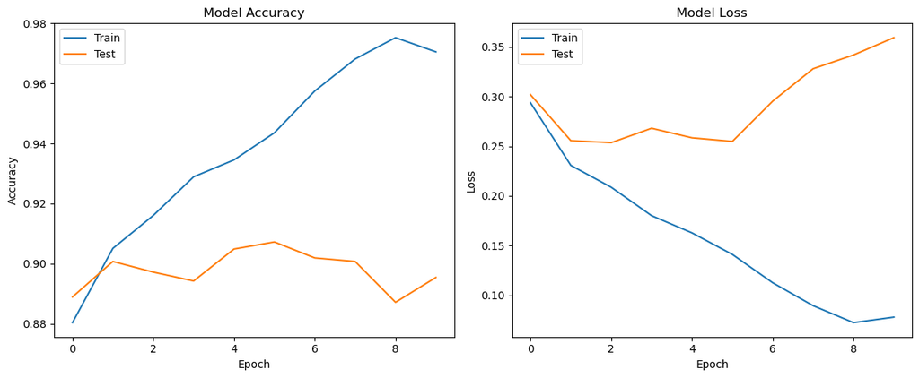

```python
plt.figure(figsize=(12, 5))
plt.subplot(1, 2, 1)
plt.plot(history6.history['accuracy'])
plt.plot(history6.history.get('val_accuracy', []))  # Optional: if validation accuracy is available
plt.title('Model Accuracy')
plt.ylabel('Accuracy')
plt.xlabel('Epoch')
plt.legend(['Train', 'Test'], loc='upper left')

# Plot training & validation loss values
plt.subplot(1, 2, 2)
plt.plot(history6.history['loss'])
plt.plot(history6.history.get('val_loss', []))  # Optional: if validation loss is available
plt.title('Model Loss')
plt.ylabel('Loss')
plt.xlabel('Epoch')
plt.legend(['Train', 'Test'], loc='upper left')

plt.tight_layout()
plt.show()
```

```python
# Predictions
y_pred = []
y_true = []

for i in range(len(test_generator)):
    x, y = test_generator[i]
    y_pred.extend(model.predict(x).flatten() > 0.5)
    y_true.extend(y)

# Convert predictions and true values to numpy arrays
y_pred = np.array(y_pred)
y_true = np.array(y_true)

# Confusion Matrix
cm = confusion_matrix(y_true, y_pred)

# Calculate Precision, Recall, F1-score, and Accuracy
precision = precision_score(y_true, y_pred)
recall = recall_score(y_true, y_pred)
f1 = f1_score(y_true, y_pred)
accuracy = accuracy_score(y_true, y_pred)

print("Confusion Matrix:")
print(cm)
print("Precision:", precision)
print("Recall:", recall)
print("F1-score:", f1)
print("Accuracy:", accuracy)
```

[output not shown]